# Fraud Prediction in Fintech

### Amount Distribution: Fraud vs Legitimate

[figure not shown]

```python
fig, ax = plt.subplots(figsize=(10, 5))
ax.hist(np.log1p(legit['amount_usd']), bins=60, alpha=0.6,
        label='Legitimate', color='#4A90D9')
ax.hist(np.log1p(fraud['amount_usd']), bins=60, alpha=0.6,
        label='Fraudulent', color='#E05252')
ax.set_title('log(1 + Amount USD) Distribution — Fraud vs Legitimate',
             fontsize=13, fontweight='bold')
ax.set_xlabel('log(1 + Amount USD)')
ax.set_ylabel('Count')
ax.legend()
plt.tight_layout()
plt.savefig(p('outputs', 'figures', '04_amount_distribution.png'), bbox_inches='tight')
plt.show()
```

Fraudulent transactions maintain a consistently low but persistent presence across all amount ranges, confirming that fraudsters operate at every spending level

### Correlation Heatmap

```python
num_features = [
    'amount_usd', 'account_age_months', 'tx_count_30d', 'avg_tx_amount_30d',
    'failed_tx_7d', 'login_attempts_24h', 'distinct_countries_30d',
    'amount_vs_avg_ratio', 'ip_country_mismatch', 'is_new_device',
    'is_night_tx', 'is_fraud'   # velocity_flag removed
]
```

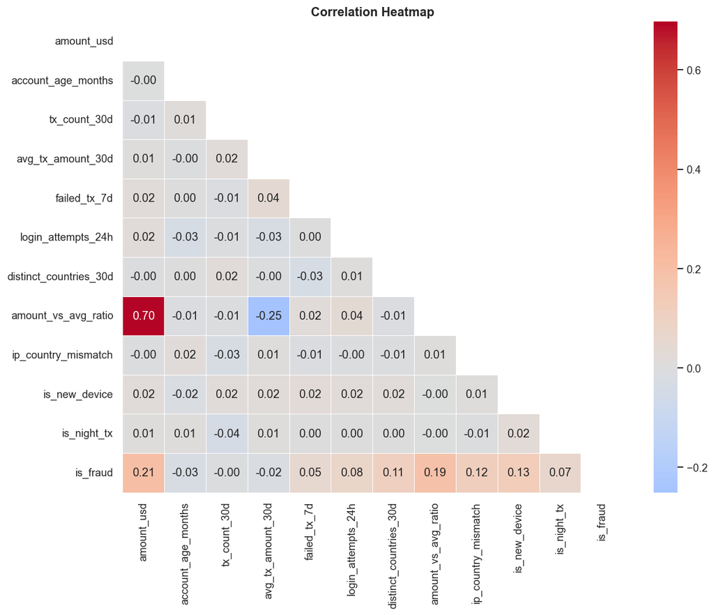

```python
num_features = [
    'amount_usd', 'account_age_months', 'tx_count_30d', 'avg_tx_amount_30d',
    'failed_tx_7d', 'login_attempts_24h', 'distinct_countries_30d',
    'amount_vs_avg_ratio', 'ip_country_mismatch', 'is_new_device',
    'is_night_tx', 'is_fraud'
]
corr = df[num_features].corr()
mask = np.triu(np.ones_like(corr, dtype=bool))

fig, ax = plt.subplots(figsize=(11, 9))
sns.heatmap(corr, mask=mask, annot=True, fmt='.2f', cmap='coolwarm',
            center=0, linewidths=0.5, ax=ax)
ax.set_title('Correlation Heatmap', fontsize=13, fontweight='bold')
plt.tight_layout()
plt.savefig(p('outputs', 'figures', '05_correlation_heatmap.png'), bbox_inches='tight')
plt.show()
```

- **amount_usd** shows the strongest positive correlation with **is_fraud (0.21)**, meaning higher transaction amounts are the single biggest linear fraud indicator in the dataset.
- **amount_vs_avg_ratio** correlates strongly with **amount_usd (0.70)** — expected, since the ratio is derived from amount — while its correlation with **is_fraud (0.19)** confirms that transacting far above one's own average is a reliable fraud signal.
- **ip_country_mismatch (0.12)**, **is_new_device (0.13)**, and **distinct_countries_30d (0.11)** all show meaningful positive correlations with fraud, validating their inclusion as key risk features in the model.

### Fraud Rate by Hour of Day

[figure not shown]

```python
fraud_by_hour = df.groupby('hour')['is_fraud'].mean()

fig, ax = plt.subplots(figsize=(12, 4))
ax.plot(fraud_by_hour.index, fraud_by_hour.values,
        marker='o', color='#E05252', lw=2, markersize=5)
ax.fill_between(fraud_by_hour.index, fraud_by_hour.values,
                alpha=0.15, color='#E05252')
ax.yaxis.set_major_formatter(mtick.PercentFormatter(1.0))
ax.set_title('Fraud Rate by Hour of Day', fontsize=13, fontweight='bold')
ax.set_xlabel('Hour of Day')
ax.set_xticks(range(0, 24))
plt.tight_layout()
plt.savefig(p('outputs', 'figures', '06_fraud_by_hour.png'), bbox_inches='tight')
plt.show()
```

### Fraud Rate by Global Region

[figure not shown]

```python
fraud_by_region = (df.groupby('region')['is_fraud']
                     .mean()
                     .sort_values(ascending=True))

fig, ax = plt.subplots(figsize=(9, 4))
fraud_by_region.plot(kind='barh', ax=ax, color='#7B68EE', width=0.6)
ax.xaxis.set_major_formatter(mtick.PercentFormatter(1.0))
ax.set_title('Fraud Rate by Global Region', fontsize=13, fontweight='bold')
ax.set_xlabel('Fraud Rate')
plt.tight_layout()
plt.savefig(p('outputs', 'figures', '07_fraud_by_region.png'), bbox_inches='tight')
plt.show()
```

### PHASE 4 — FEATURE ENGINEERING

### load cleaned data fresh

```python
cleaned_path = p('data', 'processed', 'finshield_cleaned.csv')
df = pd.read_csv(cleaned_path)

print(f"Cleaned data loaded: {df.shape}")
print(f"Fraud rate: {df['is_fraud'].mean():.2%}")
print(f"\nDtypes:\n{df.dtypes.value_counts()}")
```

```
Cleaned data loaded: (3000, 28)
Fraud rate: 28.33%

Dtypes:
int64      12
object     10
float64     6
Name: count, dtype: int64
```

### feature engineering in memory

```python
fe = df.copy()

# Log transforms
fe['log_amount']       = np.log1p(fe['amount_usd'])
fe['log_avg_tx_amt']   = np.log1p(fe['avg_tx_amount_30d'])
fe['log_amount_ratio'] = np.log1p(fe['amount_vs_avg_ratio'])

#  Composite risk score
fe['risk_score'] = (
    fe['ip_country_mismatch']                        * 2.0 +
    fe['is_new_device']                              * 1.5 +
    fe['is_night_tx']                                * 1.0 +
    fe['velocity_flag']                              * 1.5 +
    (fe['failed_tx_7d'] >= 3).astype(int)            * 2.0 +
    (fe['login_attempts_24h'] >= 5).astype(int)      * 1.5 +
    (fe['distinct_countries_30d'] >= 4).astype(int)  * 2.0 +
    (fe['account_age_months'] < 3).astype(int)       * 1.0
)

#  KYC ordinal encoding
kyc_map = {'unverified': 0, 'basic': 1, 'enhanced': 2, 'premium': 3}
fe['kyc_encoded'] = fe['kyc_tier'].map(kyc_map)

#  One-hot encode categoricals
ohe_cols = ['channel', 'merchant_category', 'payment_method', 'device_type', 'region']
fe = pd.get_dummies(fe, columns=ohe_cols, drop_first=True)

#  Convert ALL bool columns to int
bool_cols = fe.select_dtypes(include='bool').columns.tolist()
fe[bool_cols] = fe[bool_cols].astype(int)

# Drop irrelevant columns
drop_cols = [
    'transaction_id', 'customer_id', 'timestamp', 'country', 'kyc_tier',
    'amount_usd', 'avg_tx_amount_30d', 'amount_vs_avg_ratio'
]
fe = fe.drop(columns=drop_cols, errors='ignore')

print(f"✅ Feature set shape: {fe.shape}")
print(f"   Fraud rate: {fe['is_fraud'].mean():.2%}")
print(f"\nDtype summary:\n{fe.dtypes.value_counts()}")
print(f"\nAny nulls: {fe.isnull().sum().sum()}")
print(f"Any inf:   {np.isinf(fe.select_dtypes(include=np.number)).sum().sum()}")
print(f"\nTarget distribution:\n{fe['is_fraud'].value_counts()}")
```

```
✅ Feature set shape: (3000, 54)
   Fraud rate: 28.33%

Dtype summary:
int64      47
float64     7
Name: count, dtype: int64

Any nulls: 0
Any inf:   0

Target distribution:
is_fraud
0    2150
1     850
Name: count, dtype: int64
```

### signal check — fraud vs legit means

```python
# Check that key features actually separate fraud from legit
# If these show no difference, the cleaned data itself has an issue

fraud_mask = fe['is_fraud'] == 1
legit_mask = fe['is_fraud'] == 0

check_cols = ['risk_score', 'log_amount_ratio', 'log_amount',
              'ip_country_mismatch', 'is_new_device', 'kyc_encoded']

print("Feature means — Fraud vs Legitimate:")
print("─" * 45)
for col in check_cols:
    if col in fe.columns:
        fraud_mean = fe.loc[fraud_mask, col].mean()
        legit_mean = fe.loc[legit_mask, col].mean()
        diff       = fraud_mean - legit_mean
        print(f"  {col:<25}  fraud={fraud_mean:.3f}  legit={legit_mean:.3f}  diff={diff:+.3f}")
```

```
Feature means — Fraud vs Legitimate:
─────────────────────────────────────────────
  risk_score                 fraud=1.232  legit=0.667  diff=+0.566
  log_amount_ratio           fraud=1.266  legit=0.898  diff=+0.369
  log_amount                 fraud=5.244  legit=4.748  diff=+0.495
  ip_country_mismatch        fraud=0.213  legit=0.121  diff=+0.092
  is_new_device              fraud=0.264  legit=0.154  diff=+0.110
  kyc_encoded                fraud=1.479  legit=1.666  diff=-0.187
```

### train/test split

```python
X = fe.drop(columns=['is_fraud'])
y = fe['is_fraud']

X_train, X_test, y_train, y_test = train_test_split(
    X, y, test_size=0.20, random_state=42, stratify=y
)

print(f"Train: {X_train.shape}  |  Test: {X_test.shape}")
print(f"Train fraud rate: {y_train.mean():.2%}  |  Test fraud rate: {y_test.mean():.2%}")
```

```
Train: (2400, 53)  |  Test: (600, 53)
Train fraud rate: 28.33%  |  Test fraud rate: 28.33%
```

### PHASE 5 — MODEL TRAINING & EVALUATION

### SMOTE (Synthetic Minority Over-sampling Technique)

Handling class imbalance in the training data.

```python
smote = SMOTE(random_state=42, k_neighbors=5)
X_train_res, y_train_res = smote.fit_resample(X_train, y_train)

print(f"✅ After SMOTE: {X_train_res.shape}")
print(f"   Class counts: {pd.Series(y_train_res).value_counts().to_dict()}")
```

```
✅ After SMOTE: (3440, 53)
   Class counts: {0: 1720, 1: 1720}
```

### Scale + Train All Models

```python
scaler         = StandardScaler()
X_train_scaled = scaler.fit_transform(X_train_res)
X_test_scaled  = scaler.transform(X_test)

joblib.dump(scaler, p('models', 'scaler.pkl'))

# Logistic Regression
lr = LogisticRegression(max_iter=1000, random_state=42, class_weight='balanced')
lr.fit(X_train_scaled, y_train_res)
print("✅ Logistic Regression trained.")

# Random Forest
rf = RandomForestClassifier(
    n_estimators=200, max_depth=12, min_samples_leaf=5,
    class_weight='balanced', random_state=42, n_jobs=-1
)
rf.fit(X_train_res, y_train_res)
print("✅ Random Forest trained.")

# XGBoost
scale_pos = (y_train_res == 0).sum() / (y_train_res == 1).sum()
xgb = XGBClassifier(
    n_estimators=300, max_depth=6, learning_rate=0.05,
    subsample=0.8, colsample_bytree=0.8,
    scale_pos_weight=scale_pos,
    eval_metric='aucpr',
    random_state=42, n_jobs=-1
)
xgb.fit(X_train_res, y_train_res,
        eval_set=[(X_test, y_test)], verbose=False)
print("✅ XGBoost trained.")
```

```
✅ Logistic Regression trained.
✅ Random Forest trained.
✅ XGBoost trained.
```

### Compare Models

```python
models = {
    'Logistic Regression': (lr,  X_test_scaled),
    'Random Forest':       (rf,  X_test),
    'XGBoost':             (xgb, X_test),
}

results = {}
for name, (model, X_eval) in models.items():
    y_pred = model.predict(X_eval)
    y_prob = model.predict_proba(X_eval)[:, 1]
    results[name] = {
        'ROC-AUC':       round(roc_auc_score(y_test, y_prob), 4),
        'Avg Precision': round(average_precision_score(y_test, y_prob), 4),
        'F1 (Fraud)':    round(f1_score(y_test, y_pred), 4),
    }

comparison_df = pd.DataFrame(results).T
print("═" * 52)
print("           MODEL COMPARISON")
print("═" * 52)
print(comparison_df.to_string())

comparison_df.to_csv(p('outputs', 'reports', 'model_comparison.csv'))
```

```
════════════════════════════════════════════════════
           MODEL COMPARISON
════════════════════════════════════════════════════
                     ROC-AUC  Avg Precision  F1 (Fraud)
Logistic Regression   0.6990         0.4707      0.3383
Random Forest         0.7050         0.4700      0.3985
XGBoost               0.7115         0.4783      0.4270
```

- XGBoost outperforms all models across every metric: **ROC-AUC (0.712)**, **Avg Precision (0.478)**, and **F1 (0.427)** , making it the clear choice as the production model for the FinShield AI fraud detection system.

### XGBoost Classification Report

```python
y_pred_xgb = xgb.predict(X_test)
print("═" * 50)
print("  XGBoost — Full Classification Report")
print("═" * 50)
print(classification_report(y_test, y_pred_xgb,
                             target_names=['Legitimate', 'Fraud']))
```

```
══════════════════════════════════════════════════
  XGBoost — Full Classification Report
══════════════════════════════════════════════════
              precision    recall  f1-score   support

  Legitimate       0.78      0.88      0.82       430
       Fraud       0.54      0.35      0.43       170

    accuracy                           0.73       600
   macro avg       0.66      0.62      0.63       600
weighted avg       0.71      0.73      0.71       600
```

### ROC Curve Comparison

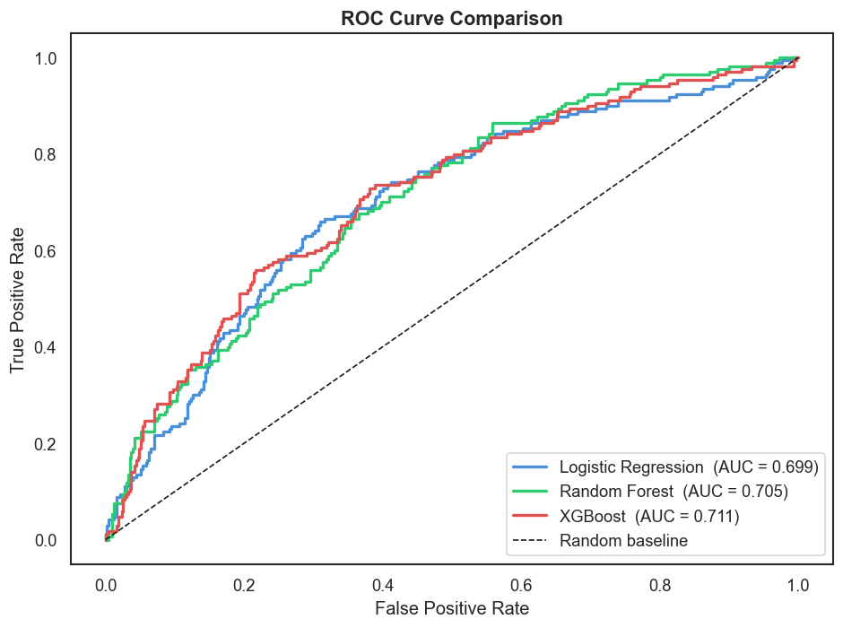

```python
fig, ax = plt.subplots(figsize=(8, 6))
colors = ['#4A90D9', '#2ECC71', '#E05252']

for (name, (model, X_eval)), color in zip(models.items(), colors):
    y_prob = model.predict_proba(X_eval)[:, 1]
    fpr, tpr, _ = roc_curve(y_test, y_prob)
    auc = roc_auc_score(y_test, y_prob)
    ax.plot(fpr, tpr, lw=2, color=color, label=f'{name}  (AUC = {auc:.3f})')

ax.plot([0, 1], [0, 1], 'k--', lw=1, label='Random baseline')
ax.set_xlabel('False Positive Rate')
ax.set_ylabel('True Positive Rate')
ax.set_title('ROC Curve Comparison', fontsize=13, fontweight='bold')
ax.legend(loc='lower right')
plt.tight_layout()
plt.savefig(p('outputs', 'figures', '08_roc_comparison.png'), bbox_inches='tight')  # ← fixed
plt.show()
```

### Confusion Matrix (XGBoost)

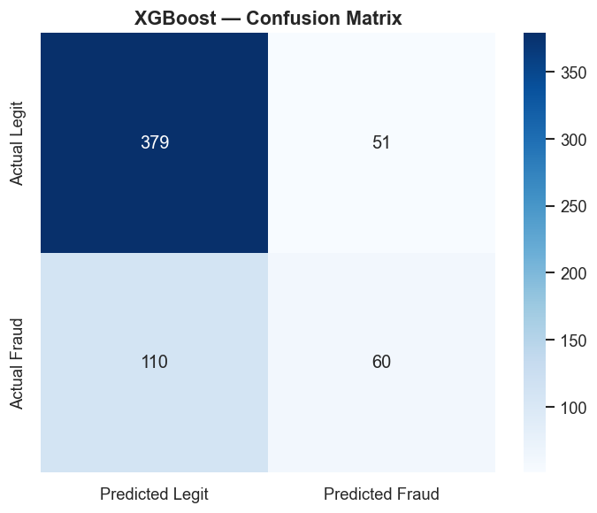

```python
cm = confusion_matrix(y_test, y_pred_xgb)

fig, ax = plt.subplots(figsize=(6, 5))
sns.heatmap(cm, annot=True, fmt='d', cmap='Blues', ax=ax,
            xticklabels=['Predicted Legit', 'Predicted Fraud'],
            yticklabels=['Actual Legit', 'Actual Fraud'])
ax.set_title('XGBoost — Confusion Matrix', fontsize=13, fontweight='bold')
plt.tight_layout()
plt.savefig(p('outputs', 'figures', '09_confusion_matrix.png'), bbox_inches='tight')
plt.show()
```

- The model correctly identified 379 legitimate transactions and 60 fraudulent ones, demonstrating reasonable ability to detect fraud while keeping false alarms manageable with only 51 legitimate transactions wrongly flagged.

### SHAP Feature Importance

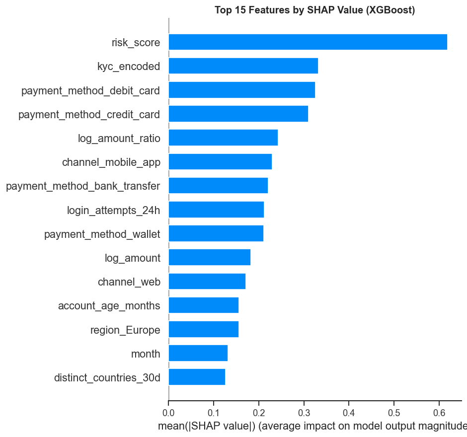

```python
explainer   = shap.TreeExplainer(xgb)
shap_values = explainer.shap_values(X_test)

shap.summary_plot(shap_values, X_test, plot_type='bar',
                  max_display=15, show=False)
plt.title('Top 15 Features by SHAP Value (XGBoost)', fontsize=12, fontweight='bold')
plt.tight_layout()
plt.savefig(p('outputs', 'figures', '10_shap_importance.png'), bbox_inches='tight')
plt.show()
```

### Save Best Model & Feature Columns

```python
model_path    = p('models', 'xgb_fraud_model.pkl')
features_json = p('models', 'feature_columns.json')

joblib.dump(xgb, model_path)

with open(features_json, 'w') as f:
    json.dump(list(X.columns), f)

print(f"✅ Model saved    →  {model_path}")
print(f"✅ Features saved →  {features_json}")
print(f"✅ Scaler saved   →  {p('models', 'scaler.pkl')}")
print("\n🎉 All model artefacts ready.")
```

```
✅ Model saved    →  C:\Users\DELL\Desktop\Data Analytics Projects\finshield_ai\models\xgb_fraud_model.pkl
✅ Features saved →  C:\Users\DELL\Desktop\Data Analytics Projects\finshield_ai\models\feature_columns.json
✅ Scaler saved   →  C:\Users\DELL\Desktop\Data Analytics Projects\finshield_ai\models\scaler.pkl

🎉 All model artefacts ready.
```

### PHASE 6 — STREAMLIT APP

### Preparing Deployment Folder

```python
import os
import shutil

username     = os.getlogin()  # Gets the currently logged-in Windows user
PROJECT_ROOT = rf"C:\Users\{username}\Desktop\Data Analytics Projects\finshield_ai"

# Deployment folder -  The 'Destination': A clean folder on the Desktop dedicated to the live app/deployment
DEPLOY_ROOT  = rf"C:\Users\{username}\Desktop\finshield_deploy"

# Create deployment folder structure
os.makedirs(os.path.join(DEPLOY_ROOT, 'models'), exist_ok=True)
print(f"✅ Deployment folder created at:\n   {DEPLOY_ROOT}")

# Copy model artefacts ( files generated during training that are needed for future prediction )
files_to_copy = [
    (p('models', 'xgb_fraud_model.pkl'),    os.path.join(DEPLOY_ROOT, 'models', 'xgb_fraud_model.pkl')),
    (p('models', 'scaler.pkl'),              os.path.join(DEPLOY_ROOT, 'models', 'scaler.pkl')),
    # A JSON list of column names (ensures the model gets features in the right order)
    (p('models', 'feature_columns.json'),   os.path.join(DEPLOY_ROOT, 'models', 'feature_columns.json')),
]

for src, dst in files_to_copy:
    shutil.copy2(src, dst)
    print(f"  ✅ Copied: {os.path.basename(src)}")

print("\n✅ Model artefacts ready for deployment.")
```

```
✅ Deployment folder created at:
   C:\Users\DELL\Desktop\finshield_deploy
  ✅ Copied: xgb_fraud_model.pkl
  ✅ Copied: scaler.pkl
  ✅ Copied: feature_columns.json

✅ Model artefacts ready for deployment.
```